# uscovid19 - Bug fixing

## Pull and Clean Data

Pull data from JHU CCI github and combine with JHU IDD data that is part of the package.

```r
library(tidyverse)
library(tidyverse)
library(lubridate)
```

# Run functions to generate data

[output not shown]

## Generate plots of all

Plot and save to check each state.

```r
dir.create("figures", recursive = TRUE, showWarnings = FALSE)
states_ <- sort(unique(vacc_data_10yr$USPS))
pages_ <- ceiling(length(states_)/9)
state_groups <- sort(rep(1:pages_, 9))[1:length(states_)]

pdf(paste0("figures/prop_vacc_by_age10yr_", Sys.Date(), ".pdf"), height=11, width = 8.5)
for (i in 1:pages_){
    state_tmp <- states_[state_groups==i]
    print(vacc_data_10yr %>% filter(USPS %in% state_tmp) %>%
              arrange(prop_vacc_age) %>%
              mutate(USPS = fct_reorder(USPS, (prop_vacc_age))) %>%
              ggplot(aes(x=date, y=prop_vacc_age, color=age_group, group=age_group)) +
              geom_line() +
              geom_point(aes(shape=source, fill=source)) +
              scale_shape_manual("Source", values = c(21, 23)) +
              scale_fill_manual("Source", values=c("orange","lightblue4")) +
              scale_color_discrete("Age group, yrs") +
              xlab("State") + ylab("proportion vaccinated") +
              ggtitle("Proportion Vaccinated, By State and Age") +
              theme_bw() +
              theme(axis.text.x = element_text(angle=90)) +
              facet_wrap(~USPS))
}
dev.off()
```

## Plot problem states to check

### 1. Major Issues

```r
usps_samp <- c("AR","DE","IA","NY","LA","MT","NH","OK","PR","WY","WV")
vacc_data_10yr %>% filter(USPS %in% usps_samp) %>%
              arrange(prop_vacc_age) %>%
              mutate(USPS = fct_reorder(USPS, (prop_vacc_age))) %>%
              ggplot(aes(x=date, y=prop_vacc_age, color=age_group, group=age_group)) +
              geom_line() +
              geom_point(aes(shape=source, fill=source)) +
              scale_shape_manual("Source", values = c(21, 23)) +
              scale_fill_manual("Source", values=c("orange","lightblue4")) +
              scale_color_discrete("Age group, yrs") +
              xlab("State") + ylab("proportion vaccinated") +
              ggtitle("Proportion Vaccinated, By State and Age") +
              theme_bw() +
              theme(axis.text.x = element_text(angle=90)) +
              facet_wrap(~USPS)
```

#### AR

- No Data reported

```r
vacc_data %>% filter(USPS=="AR")
```

#### NY

- No Data reported

```r
vacc_data %>% filter(USPS=="NY")
# missing from these data

data("idd_vacc_clean")

idd_vacc_clean %>% filter(state == "New York")
idd_vacc_data %>% filter(state == "New York")

# Pull and do a quick clean on cci Data
cci_vacc_data <- pull_cci_vacc(git_token = git_token) %>% clean_cci_vacc()

cci_vacc_data %>% filter(State=="NY")
```

No data included for NY - it exists on their dashboard though: https://covid19vaccine.health.ny.gov/vaccine-demographic-data

#### ND

- No Data reported Data are weird for ND: Pulled new data and added to package needed: https://www.health.nd.gov/covid19vaccine/dashboard

```r
plot_state_curves(vacc_age_data=vacc_data_10yr, states="ND")

state_ <- "ND"
vacc_data %>% filter(USPS==state_) %>% View()
# missing from these data

# IDD data
data("idd_vacc_clean")
idd_vacc_clean %>% filter(USPS == state_, age=="80_100") %>% arrange(date) %>% View()
idd_vacc_data %>% filter(state == "New York")
# none available

# Pull and do a quick clean on cci Data
cci_vacc_data <- pull_cci_vacc(git_token = git_token) %>% clean_cci_vacc()
cci_vacc_data %>% filter(State==state_) %>% View()

# # Dig into this function
# cci_vacc_data_clean <- process_cci_age_vacc(data=cci_vacc_data,
#                                       daily_state_vacc = daily_state_vacc,
#                                       state_pop_ageXyr = state_pop_age10yr) %>%
#     left_join(state_pop_age10yr %>% select(USPS, geoid) %>% distinct())

data=cci_vacc_data %>% filter(State==state_)
state_pop_ageXyr = state_pop_age10yr
# fixed -- dropped extra categories

plot_state_curves(vacc_age_data=vacc_data_10yr, states=state_)
```

#### DE

- Changed age groups

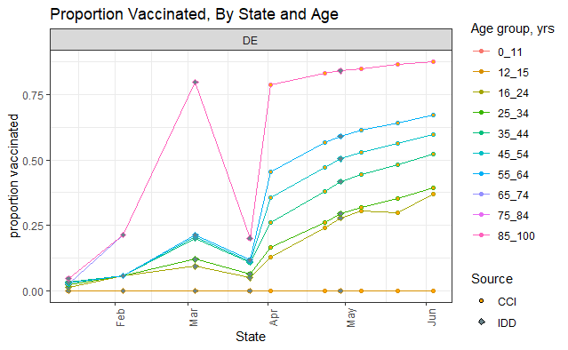

#### NJ

- Changed age groups

```r
state_ <- "NJ"

plot_state_curves(vacc_age_data=vacc_data_10yr, states=state_)

vacc_data %>% filter(USPS==state_) %>% View()
# missing from these data

# Pull and do a quick clean on cci Data
cci_vacc_data <- pull_cci_vacc(git_token = git_token) #%>% clean_cci_vacc()
cci_vacc_data %>% filter(State==state_) %>% View()

cci_vacc_data <- pull_cci_vacc(git_token = git_token) %>% clean_cci_vacc()
cci_vacc_data %>% filter(State==state_) %>% View()

# Dig into this function
cci_vacc_data_clean <- process_cci_age_vacc(data=cci_vacc_data,
                                      daily_state_vacc = daily_state_vacc,
                                      state_pop_ageXyr = state_pop_age10yr) %>%
    left_join(state_pop_age10yr %>% select(USPS, geoid) %>% distinct())

data=cci_vacc_data %>% filter(State==state_)
state_pop_ageXyr = state_pop_age10yr


plot_state_curves(vacc_age_data=vacc_data_10yr, states=state_)

vacc_data_10yr %>% filter(USPS==state_) %>% View()
```

NJ is problematic since they only report 2 doses. We are currently using the proportions to assume proportion of first doses, but that is overestimating older group coverage.

#### NV

- Changed age groups

```r
# Pull and do a quick clean on cci Data
cci_vacc_data <- pull_cci_vacc(git_token = git_token) #%>% clean_cci_vacc()
```

#### DC

- Changed age groups

```r
state_ <- "DC"
vacc_data %>% filter(USPS==state_) %>% View()
# missing from these data

# IDD data
data("idd_vacc_clean")
idd_vacc_clean %>% filter(USPS == state_)
idd_vacc_data %>% filter(state == "New York")
# none available

# Pull and do a quick clean on cci Data
cci_vacc_data <- pull_cci_vacc(git_token = git_token) %>% clean_cci_vacc()
cci_vacc_data %>% filter(State==state_) %>% View()

# # Dig into this function
# cci_vacc_data_clean <- process_cci_age_vacc(data=cci_vacc_data,
#                                       daily_state_vacc = daily_state_vacc,
#                                       state_pop_ageXyr = state_pop_age10yr) %>%
#     left_join(state_pop_age10yr %>% select(USPS, geoid) %>% distinct())

data=cci_vacc_data %>% filter(State==state_)
state_pop_ageXyr = state_pop_age10yr
# fixed -- dropped extra categories

plot_state_curves(vacc_age_data=vacc_data_10yr, states=state_)
```

#### LA

- Changed age groups

```r
state_ <- "LA"

plot_state_curves(vacc_age_data=vacc_data_10yr, states=state_)

# Pull Raw CCI data
cci_vacc_data <- pull_cci_vacc(git_token = git_token) %>% clean_cci_vacc()
cci_vacc_data %>% filter(State==state_) %>% View()


# IDD data
data("idd_vacc_clean")
idd_vacc_clean %>% filter(USPS == state_)
idd_vacc_data %>% filter(state == "New York")
# none available



# # Dig into this function
# cci_vacc_data_clean <- process_cci_age_vacc(data=cci_vacc_data,
#                                       daily_state_vacc = daily_state_vacc,
#                                       state_pop_ageXyr = state_pop_age10yr) %>%
#     left_join(state_pop_age10yr %>% select(USPS, geoid) %>% distinct())

data=cci_vacc_data %>% filter(State==state_)
state_pop_ageXyr = state_pop_age10yr
# fixed -- dropped extra categories

plot_state_curves(vacc_age_data=vacc_data_10yr, states=state_)
```

#### NC

- No Data reported

```r
state_="NC"
plot_state_curves(vacc_age_data=vacc_data_10yr, states=state_)

vacc_data %>% filter(USPS==state_) %>% View()
# missing from these data


# Pull and do a quick clean on cci Data
cci_vacc_data <- pull_cci_vacc(git_token = git_token) %>% clean_cci_vacc()
cci_vacc_data %>% filter(State==state_) %>% View()
```

Appears to be a reporting issue for 2 dates. Drop: “2021-03-24” and “2021-04-02”

### 2. Moderate Issues

```r
usps_samp <- c("FL","MN","MA","MD","HI","IL","MT","NJ","NE","NC","NM","NV")
vacc_data_10yr %>% filter(USPS %in% usps_samp) %>%
              arrange(prop_vacc_age) %>%
              mutate(USPS = fct_reorder(USPS, (prop_vacc_age))) %>%
              ggplot(aes(x=date, y=prop_vacc_age, color=age_group, group=age_group)) +
              geom_line() +
              geom_point(aes(shape=source, fill=source)) +
              scale_shape_manual("Source", values = c(21, 23)) +
              scale_fill_manual("Source", values=c("orange","lightblue4")) +
              scale_color_discrete("Age group, yrs") +
              xlab("State") + ylab("proportion vaccinated") +
              ggtitle("Proportion Vaccinated, By State and Age") +
              theme_bw() +
              theme(axis.text.x = element_text(angle=90)) +
              facet_wrap(~USPS)
```

### 3. Minor Issues

```r
usps_samp <- c("SC","RI","PA","TX","SD","WA","VT","VA","UT")
vacc_data_10yr %>% filter(USPS %in% usps_samp) %>%
              arrange(prop_vacc_age) %>%
              mutate(USPS = fct_reorder(USPS, (prop_vacc_age))) %>%
              ggplot(aes(x=date, y=prop_vacc_age, color=age_group, group=age_group)) +
              geom_line() +
              geom_point(aes(shape=source, fill=source)) +
              scale_shape_manual("Source", values = c(21, 23)) +
              scale_fill_manual("Source", values=c("orange","lightblue4")) +
              scale_color_discrete("Age group, yrs") +
              xlab("State") + ylab("proportion vaccinated") +
              ggtitle("Proportion Vaccinated, By State and Age") +
              theme_bw() +
              theme(axis.text.x = element_text(angle=90)) +
              facet_wrap(~USPS)
```

WA - Problem with 2nd and 3rd dates.

```r
# load raw data
data(idd_vacc_data)

wa_idd <- idd_vacc_data %>% filter(state=="Washington")

wa_all <- vacc_data_10yr %>% filter(state=="Washington")
```

Looks like it’s a problem with the population numbers and different data structure reported. Current fix: Drop “2021-02-16” for WA

#### RI

```r
vacc_data %>% filter(USPS=="RI")
```

Drop last IDD point

#### SC

```r
vacc_data %>% filter(USPS=="SC")
```

Something weird with data for last date.

### New Rules to implement:

# Drop the above issues

```r
drop_dates_vaccdat <- function(vacc_data_Xyr = vacc_data_10yr){

    vacc_data_Xyr <- vacc_data_Xyr %>%
        filter(
            !(USPS=="TX" & date=="2021-03-27"),
            !(USPS=="WA" & date %in% c("2021-02-16","2021-03-24")),
            !(USPS=="VA" & date=="2021-05-07"),
            !(USPS=="VT" & date=="2021-05-07"),
            !(USPS=="RI" & date=="2021-05-07"),
            !(USPS=="NC" & date=="2021-05-07"),
            !(USPS=="DE" & (date=="2021-03-25" | (age_group=="85_100" & date=="2021-04-02"))),
            !(USPS=="NC" & (date=="2021-03-24" | date=="2021-04-02") & (age_l>=65)),
            !(USPS=="ND" & date<=lubridate::as_date("2021-06-04"))
            # filter(!(USPS=="IA" & date==lubridate::as_date("2021-04-02"))) %>%
            # filter(!(USPS=="HI" & date==lubridate::as_date("2021-04-02")))
        )

    return(vacc_data_Xyr)
}
```

```r
vacc_data_10yr <- drop_dates_vaccdat(vacc_data_Xyr = vacc_data_10yr)
```

## Generate plots of all

Plot and save to check each state.

```r
dir.create("figures", recursive = TRUE, showWarnings = FALSE)
states_ <- sort(unique(vacc_data_10yr$USPS))
pages_ <- ceiling(length(states_)/9)
state_groups <- sort(rep(1:pages_, 9))[1:length(states_)]

pdf(paste0("figures/prop_vacc_by_age10yr_", Sys.Date(), "_cleaned.pdf"), height=11, width = 8.5)
for (i in 1:pages_){
    state_tmp <- states_[state_groups==i]
    print(vacc_data_10yr %>% filter(USPS %in% state_tmp) %>%
              arrange(prop_vacc_age) %>%
              mutate(USPS = fct_reorder(USPS, (prop_vacc_age))) %>%
              ggplot(aes(x=date, y=prop_vacc_age, color=age_group, group=age_group)) +
              geom_line() +
              geom_point(aes(shape=source, fill=source)) +
              scale_shape_manual("Source", values = c(21, 23)) +
              scale_fill_manual("Source", values=c("orange","lightblue4")) +
              scale_color_discrete("Age group, yrs") +
              xlab("State") + ylab("proportion vaccinated") +
              ggtitle("Proportion Vaccinated, By State and Age") +
              theme_bw() +
              theme(axis.text.x = element_text(angle=90)) +
              facet_wrap(~USPS))
}
dev.off()
```

## Go through data pull and cleaning step-by-step to identify problems

Through the package, this is done using `vacc_data <- get_clean_us_agevacc(git_token = git_token)`

```r
git_token = git_token

# Load state populations & IDD data
data("state_pop_age5yr")
data("idd_vacc_clean")

# Load latest vaccination by state
daily_state_vacc <- suppressMessages(get_state_vacc() %>% filter(!is.na(dose1)))


# pull and process CCI data

# Pull and do a quick clean on cci Data
cci_vacc_data <- pull_cci_vacc(git_token = git_token)
```

### Look at problem states.

```r
cci_vacc_data
```

# Pull Data from JHU CCI github and combine with JHU IDD data

```r
# Get clean, but not age group standardized data
vacc_data <- get_clean_us_agevacc(git_token = git_token)

# Make it standardized to either 5yr or 10 year age groups
vacc_data_5yr <- get_standardized_us_agevacc(vacc_data = vacc_data,
                                        age_groups = "5yr", # "10yr"
                                        git_token = git_token)

# Make it standardized to either 5yr or 10 year age groups
vacc_data_10yr <- get_standardized_us_agevacc(vacc_data = vacc_data,
                                        age_groups = "10yr",
                                        git_token = git_token)
```